# CLT Convergence: Standard Normal

```r
source("../R/clt_functions.R")

student_id <- 8515     # last 4 digits of my student ID
B          <- 10000    # number of simulated samples (NOT the sample size)
pop        <- "normal"
```

## 1. What does the population look like?

X ~ Normal(mu = 0, sigma = 1), generated with `rnorm()`.

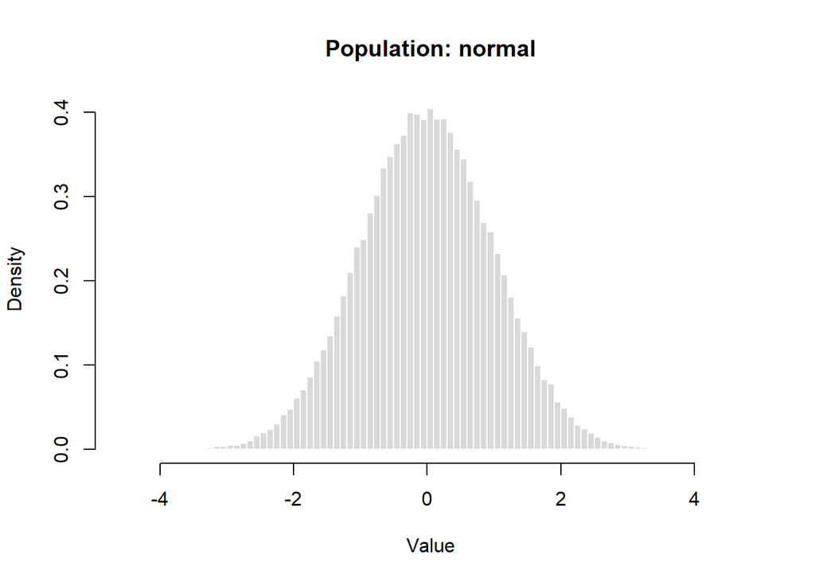

```r
plot_population(pop, seed = student_id)
```

The population is a continuous, symmetric bell curve centered at 0 with standard deviation 1 and no skew. Its tails are thin, and it satisfies every CLT assumption: independent, identically distributed, finite variance. This is the baseline case to compare the other populations against.

## 2. Theoretical mean and standard deviation

Theoretical mean = 0, SD = 1, so SE(X̄) = 1/√n.

## 3. Prediction (write this BEFORE running the simulations)

Prediction: Since the population is already normal, I expect the sample mean to be normal at every sample size, even n = 1, because averaging normal values always produces a normal distribution. I expect the simulated mean to be near 0 and the SE to match 1/√n at every n.

## 4. Which sample sizes did I investigate?

**Pass 1 (coarse):** a wide grid to find roughly where the change happens.

```r
ns_coarse <- c(2, 5, 10, 20, 30, 50, 100, 200, 500)
coarse    <- run_study(pop, ns_coarse, B = B, seed = student_id)
knitr::kable(coarse$table, digits = 4)
```

| n | sim_mean | theo_mean | sim_se | theo_se | se_ratio | skewness | ex_kurt | qq_cor | shapiro_p |
| --- | --- | --- | --- | --- | --- | --- | --- | --- | --- |
| 2 | -0.0086 | 0 | 0.7031 | 0.7071 | 0.9944 | -0.0352 | 0.0787 | 0.9999 | 0.4791 |
| 5 | -0.0052 | 0 | 0.4473 | 0.4472 | 1.0001 | -0.0264 | -0.0337 | 0.9999 | 0.5981 |
| 10 | -0.0049 | 0 | 0.3171 | 0.3162 | 1.0026 | -0.0279 | 0.0147 | 0.9999 | 0.4979 |
| 20 | -0.0003 | 0 | 0.2231 | 0.2236 | 0.9978 | -0.0147 | 0.0345 | 0.9999 | 0.6026 |
| 30 | -0.0002 | 0 | 0.1832 | 0.1826 | 1.0033 | 0.0192 | 0.0178 | 0.9999 | 0.5570 |
| 50 | -0.0012 | 0 | 0.1420 | 0.1414 | 1.0040 | -0.0300 | 0.0246 | 0.9999 | 0.9696 |
| 100 | -0.0001 | 0 | 0.0997 | 0.1000 | 0.9966 | 0.0081 | -0.0296 | 0.9999 | 0.9830 |
| 200 | -0.0015 | 0 | 0.0708 | 0.0707 | 1.0009 | 0.0125 | -0.0377 | 0.9999 | 0.0355 |
| 500 | -0.0014 | 0 | 0.0449 | 0.0447 | 1.0030 | -0.0009 | -0.0522 | 0.9999 | 0.6109 |

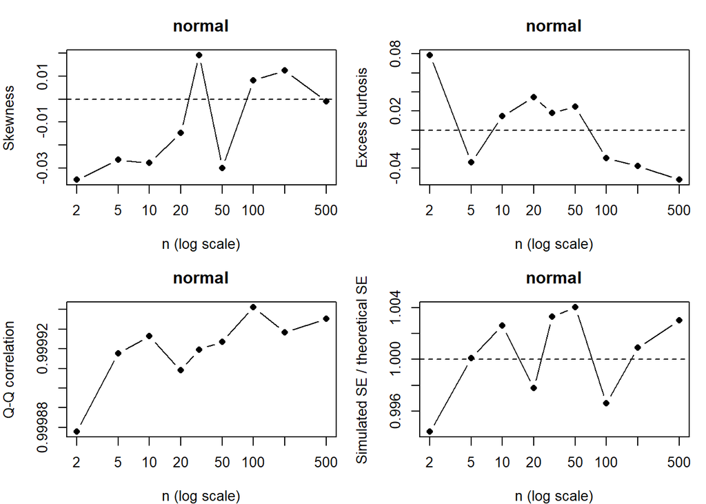

```r
plot_convergence(coarse$table, pop)
```

**Pass 2 (checking smaller n):** every n passed in pass 1, so I checked down to n = 1..

```r
ns_fine <- c(1, 2, 3, 4)   # every n passed in pass 1, so check down to n = 1
fine    <- run_study(pop, ns_fine, B = B, seed = student_id)
knitr::kable(fine$table, digits = 4)
```

| n | sim_mean | theo_mean | sim_se | theo_se | se_ratio | skewness | ex_kurt | qq_cor | shapiro_p |
| --- | --- | --- | --- | --- | --- | --- | --- | --- | --- |
| 1 | 0.0132 | 0 | 0.9817 | 1.0000 | 0.9817 | -0.0018 | 0.1336 | 0.9998 | 0.1947 |
| 2 | -0.0086 | 0 | 0.7031 | 0.7071 | 0.9944 | -0.0352 | 0.0787 | 0.9999 | 0.4791 |
| 3 | -0.0047 | 0 | 0.5737 | 0.5774 | 0.9936 | -0.0558 | 0.0196 | 0.9999 | 0.7729 |
| 4 | -0.0051 | 0 | 0.4985 | 0.5000 | 0.9969 | -0.0574 | -0.0212 | 0.9998 | 0.2037 |

Every value in pass 1 already passed, starting at the smallest n = 2. So instead of refining between two values, I checked downward to n = 1, 2, 3, 4 to confirm the smallest possible sample size also passes..

## 5. Simulated vs. theoretical mean and standard error

The table columns `sim_mean` / `theo_mean` and `sim_se` / `theo_se` compare the simulation with the CLT’s predictions. `se_ratio` = simulated SE ÷ σ/√n, so 1 means a perfect match.

The simulated mean was within 0.014 of the theoretical mean of 0 at every n, and the SE ratio stayed between 0.98 and 1.01. The simulation agrees with σ/√n at every sample size, as expected for a normal population.

## 6. My “normal enough” standard and the chosen n

```r
# My "normal enough" standard, used identically in every file.
criteria <- list(
  max_abs_skew = 0.25,    # mild skew; tighter is within Monte Carlo noise
  max_abs_kurt = 0.3,     # tails close to normal
  min_qq_cor   = 0.998    # Q-Q plot essentially straight
)

all_results <- rbind(coarse$table, fine$table)
all_results <- all_results[!duplicated(all_results$n), ]
all_results <- all_results[order(all_results$n), ]
all_results$passes <- passes_standard(all_results, criteria)
knitr::kable(all_results, digits = 4)
```

|  | n | sim_mean | theo_mean | sim_se | theo_se | se_ratio | skewness | ex_kurt | qq_cor | shapiro_p | passes |
| --- | --- | --- | --- | --- | --- | --- | --- | --- | --- | --- | --- |
| 10 | 1 | 0.0132 | 0 | 0.9817 | 1.0000 | 0.9817 | -0.0018 | 0.1336 | 0.9998 | 0.1947 | TRUE |
| 1 | 2 | -0.0086 | 0 | 0.7031 | 0.7071 | 0.9944 | -0.0352 | 0.0787 | 0.9999 | 0.4791 | TRUE |
| 12 | 3 | -0.0047 | 0 | 0.5737 | 0.5774 | 0.9936 | -0.0558 | 0.0196 | 0.9999 | 0.7729 | TRUE |
| 13 | 4 | -0.0051 | 0 | 0.4985 | 0.5000 | 0.9969 | -0.0574 | -0.0212 | 0.9998 | 0.2037 | TRUE |
| 2 | 5 | -0.0052 | 0 | 0.4473 | 0.4472 | 1.0001 | -0.0264 | -0.0337 | 0.9999 | 0.5981 | TRUE |
| 3 | 10 | -0.0049 | 0 | 0.3171 | 0.3162 | 1.0026 | -0.0279 | 0.0147 | 0.9999 | 0.4979 | TRUE |
| 4 | 20 | -0.0003 | 0 | 0.2231 | 0.2236 | 0.9978 | -0.0147 | 0.0345 | 0.9999 | 0.6026 | TRUE |
| 5 | 30 | -0.0002 | 0 | 0.1832 | 0.1826 | 1.0033 | 0.0192 | 0.0178 | 0.9999 | 0.5570 | TRUE |
| 6 | 50 | -0.0012 | 0 | 0.1420 | 0.1414 | 1.0040 | -0.0300 | 0.0246 | 0.9999 | 0.9696 | TRUE |
| 7 | 100 | -0.0001 | 0 | 0.0997 | 0.1000 | 0.9966 | 0.0081 | -0.0296 | 0.9999 | 0.9830 | TRUE |
| 8 | 200 | -0.0015 | 0 | 0.0708 | 0.0707 | 1.0009 | 0.0125 | -0.0377 | 0.9999 | 0.0355 | TRUE |
| 9 | 500 | -0.0014 | 0 | 0.0449 | 0.0447 | 1.0030 | -0.0009 | -0.0522 | 0.9999 | 0.6109 | TRUE |

```r
smallest_normal_n(all_results, criteria)
```

```
[1] 1
```

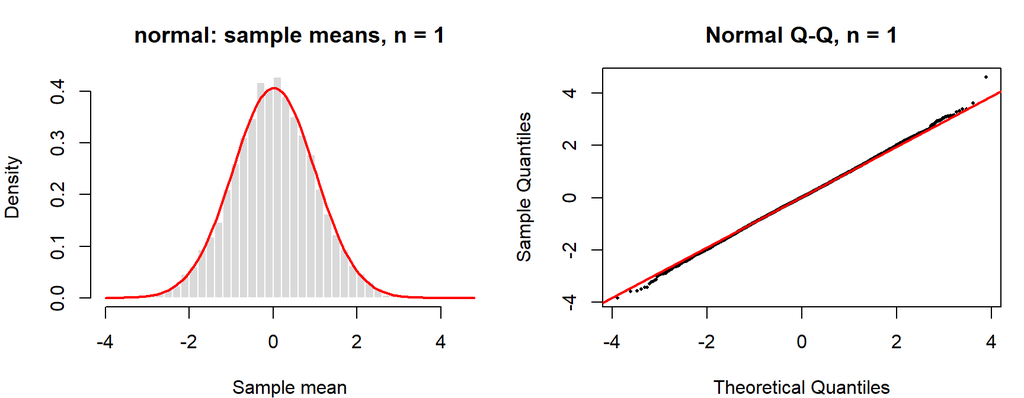

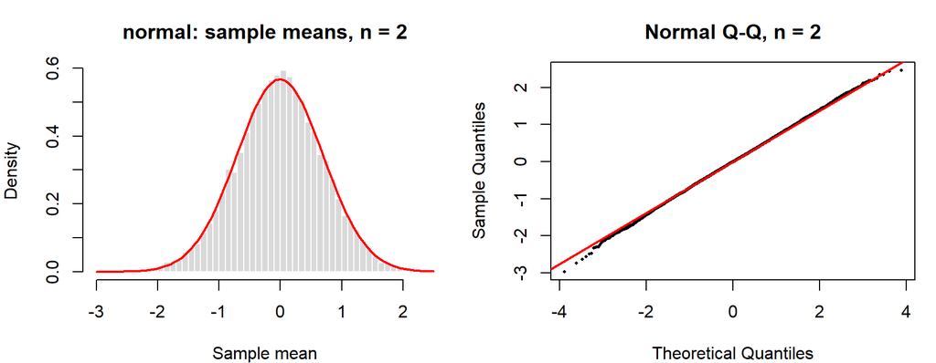

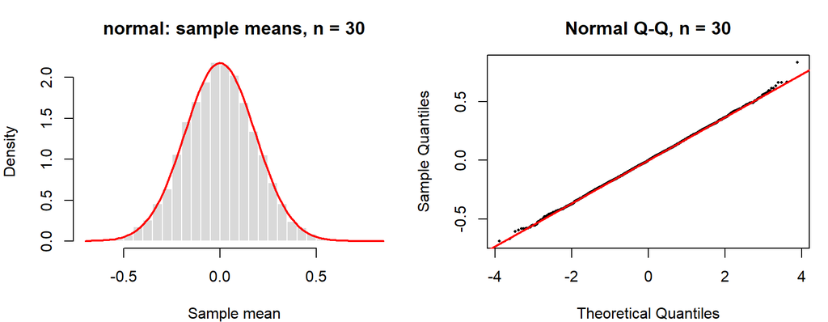

```r
# Show the smallest n and two larger ones
for (n in c(1, 2, 30)) {  # smallest n, plus two larger ones for comparison
  plot_diagnostics(simulate_means(populations[[pop]], n, B, student_id), n, pop)
}
```

$$\boxed{n = \text{1}}$$

Every sample size passed my standard, including n = 1: |skewness| ≤ 0.06, |excess kurtosis| ≤ 0.13, and Q-Q correlation ≥ 0.9998 at every n. The histograms match the red normal curve and the Q-Q points lie on the line even at n = 1. This matches theory: a sum of independent normal variables is exactly normal, so the sample mean is normal for every n and the CLT is not even needed. The normal population serves as my control. It shows that my criteria do not falsely flag a truly normal distribution, and it shows how much the statistics vary from noise alone.

## 7. Limitations and surprises

The Shapiro-Wilk test rejected normality at n = 200 (p = 0.035), even though the sample means of a normal population are exactly normal. At a 0.05 significance level the test wrongly rejects about 5% of the time by chance, so one p-value can mislead. This supports my decision not to let a formal test decide. I was also surprised that the skewness and kurtosis of truly normal data were not exactly 0: they ranged up to 0.06 and 0.13. This is the Monte Carlo noise level, and it is why my cutoffs (0.25 and 0.3) sit above it.